# Homework 8

## Please submit the solution in the form of R Markdown report, knitted into either of the available formats (HTML, pdf or Word). Provide all relevant code and output. Goal of this homework is to have you practice modeling categorical predictors (dummy variables); individual t-test and incremental F-test for significance of a categorical predictor; modeling interaction between predictors in explaining a response; your R coding

# Problem #1

For Credit data set, proceed to

1. Figure out if there’s statistical evidence of interaction between Income and Rating. Make sure to write down the full modeling equation along with hypotheses to be tested (all in parametric notation), make a conclusion. If there’s statistical evidence of interaction (otherwise - don’t do that), interpret the effects of 1) Income on Balance; and 2) Rating on Balance

$Balance_i = \beta_0+\beta_1Income_i+\beta_2Rating_i+\beta_3Income_i\times Rating_i+\epsilon_i,~\epsilon_i\sim_{ind}N(0,\sigma^2)$  
$Balance_i = \beta_0+(\beta_1+\beta_3Rating_i)Income_i+\beta_2Rating_i+\epsilon_i,~\epsilon_i\sim_{ind}N(0,\sigma^2)$  
$Balance_i = \beta_0+\tilde{\beta_1}Income_i+\beta_2Rating_i+\epsilon_i,~\epsilon_i\sim_{ind}N(0,\sigma^2)$

$H_0:\beta_3=0$  
$H_a:\beta_3\ne0$

```r
lm.obj <- lm(Balance ~ Income + Rating + Income:Rating, data = ISLR::Credit)
summary(lm.obj)$coefficients["Income:Rating",]
```

```
##    Estimate  Std. Error     t value    Pr(>|t|)
## 0.003394308 0.001185629 2.862875079 0.004421230
```

There is a significant interaction between Income and Rating because the p-value (0.0044212) < $\alpha=0.05$

**Effect of Income on Balance:**  
Per $1000 increase in Income, holding Rating constant, the average Balance will increase by (-9.6035 $+$ 0.0034 $\times Rating$) dollars

**Effect of Rating on Balance:**  
Per 1 point increase in Rating, holding Income constant, the average Balance will increase by (3.7952 $+$ 0.0034 $\times Income$) dollars

2. Figure out if there’s statistical evidence of interaction between Income and Age. Make sure to write down the full modeling equation along with hypotheses to be tested (all in parametric notation), make a conclusion. If there’s statistical evidence of interaction (otherwise - don’t do that), interpret the effects of Income and Age on Balance.

$Balance_i = \beta_0+\beta_1Income_i+\beta_2Age_i+\beta_3Income_i\times Age_i+\epsilon_i,~\epsilon_i\sim_{ind}N(0,\sigma^2)$  
$Balance_i = \beta_0+(\beta_1+\beta_3Age_i)Income_i+\beta_2Age_i+\epsilon_i,~\epsilon_i\sim_{ind}N(0,\sigma^2)$  
$Balance_i = \beta_0+\tilde{\beta_1}Income_i+\beta_2Age_i+\epsilon_i,~\epsilon_i\sim_{ind}N(0,\sigma^2)$

$H_0:\beta_3=0$  
$H_a:\beta_3\ne0$

```r
lm.obj <- lm(Balance ~ Income + Age + Income:Age, data = ISLR::Credit)
summary(lm.obj)$coefficients["Income:Age",]
```

```
##   Estimate Std. Error    t value   Pr(>|t|)
## 0.02548648 0.03211953 0.79348844 0.42796848
```

```r
lm.obj <- lm(Balance ~ Income + Age, data = ISLR::Credit)
lm.obj$coefficients
```

```
## (Intercept)      Income         Age
##  359.672743    6.235879   -2.185067
```

**Effect of Age on Balance:**  
Per 1 year increase in Age, holding Income constant, the average Balance will increase by -2.1851 dollars

3. In case interaction term is not statistically significant, would it be beneficial to drop it? Or should we still retain it? Why (give a couple reasons)?  
   In case interaction term is not statistically significant, it is beneficial to drop it and then only interpret the main effects because the interpretations are more useful and all-encompassing

# Problem #2

For the Wage data set from ISLR package, in studying whether there’s an interaction between

1. age and job class
2. age and marital status

in explaining person’s wage, proceed to do the following:

```
a. Provide data visualization that will help determine if there’s a strong interaction between respective variables in explaining the response. Comment on whether you observe an interaction. Explain.
b. Proceed to confirm your hunch from part 2(a) by actually writing out the appropriate model, fitting it, and conducting the respective statistical test for significance of the overall interaction. Make sure to write out all the steps of the respective hypothesis testing procedures, from stating the hypotheses, down to conclusion
c. If you found an overall significant interaction, proceed to interpret only the significant individual interaction terms. Otherwise, if the overall interaction is not significant - what should be your following steps (simply list them, no need to actually perform them)?
```

### age and job class

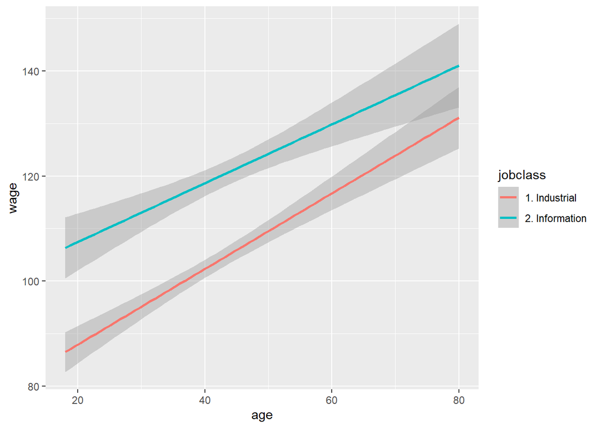

$wage_i=\beta_0+\beta_1age_i+\beta_2D_{jobclass}+\beta_3(age_i\times D_{jobclass,i})+\epsilon_i,~\epsilon_i\sim_{ind}N(0,\sigma^2)$

$wage_i=\left\{ \begin{array}{cl}\beta_0+\beta_1age_i+\beta_2+\beta_3age_i+\epsilon_i,&i^{th}~worker~has~Information~job \\ \beta_0+\beta_1age_i+\epsilon_i,&i^{th}~worker~has~Industrial~job \end{array} \right.$

$wage_i=\left\{ \begin{array}{cl}(\beta_0+\beta_2)+(\beta_1+\beta_3)age_i+\epsilon_i,&i^{th}~worker~has~Information~job \\ \beta_0+\beta_1age_i+\epsilon_i,&i^{th}~worker~has~Industrial~job \end{array} \right.$

```r
lm.obj <- lm(wage ~ age + jobclass + age:jobclass, data = ISLR::Wage)
```

Coeficient Summary

|  | Estimate | Std. Error | t value | Pr(>\|t\|) |
| --- | --- | --- | --- | --- |
| (Intercept) | 73.5283 | 3.7613 | 19.5485 | 0.0000 |
| age | 0.7197 | 0.0874 | 8.2304 | 0.0000 |
| jobclass2. Information | 22.7309 | 5.6314 | 4.0364 | 0.0001 |
| age:jobclass2. Information | -0.1602 | 0.1279 | -1.2528 | 0.2104 |

$\hat{wage} =73.5283+0.7197age+22.7309D_{jobclass}+-0.1602(age\times D_{jobclass})$

$\hat{wage}=\left\{ \begin{array}{cl}(73.5283+22.7309)+(0.7197+-0.1602)age_i+\epsilon_i,&i^{th}~worker~has~Information~job \\ 73.5283+0.7197age_i+\epsilon_i,&i^{th}~worker~has~Industrial~job \end{array} \right.$

$\hat{wage}=\left\{ \begin{array}{cl}96.2592+0.5595age_i+\epsilon_i,&i^{th}~worker~has~Information~job \\ 73.5283+0.7197age_i+\epsilon_i,&i^{th}~worker~has~Industrial~job \end{array} \right.$

### age and maritl

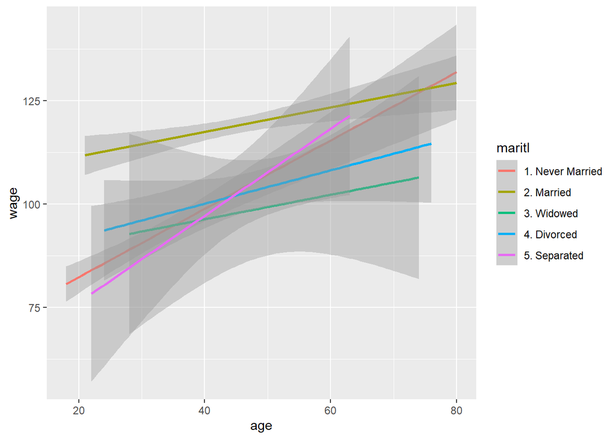

$wage_i = \beta_0+\beta_1age_i+\beta_2D_{married,i}+\beta_3D_{widowed,i}+\beta_4D_{divorced,i}+\beta_5D_{separated,i}+ \\ \beta_6(age\times D_{married,i})+\beta_7(age\times D_{widowed,i})+\beta_8(age\times D_{divorced,i})+\beta_9(age\times D_{separated,i})+\epsilon_i$

$wage_i = \left\{ \begin{array}{cl}(\beta_0+\beta_2)+(\beta_1+\beta_6)age_i+\epsilon_i,&i^{th}~person~is~married \\ (\beta_0+\beta_3)+(\beta_1+\beta_7)age_i+\epsilon_i,&i^{th}~person~is~widowed \\ (\beta_0+\beta_4)+(\beta_1+\beta_8)age_i+\epsilon_i,&i^{th}~person~is~divorced \\ (\beta_0+\beta_5)+(\beta_1+\beta_9)age_i+\epsilon_i,&i^{th}~person~is~separated \\ \beta_0+\beta_1age_i+\epsilon_i,&i^{th}~person~never~married \end{array} \right.$  
$,~\epsilon_i\sim_{ind}N(0,\sigma^2)$

```r
lm.obj <- lm(wage ~ age + maritl + age:maritl, data = ISLR::Wage)
```

Coeficient Summary

|  | Estimate | Std. Error | t value | Pr(>\|t\|) |
| --- | --- | --- | --- | --- |
| (Intercept) | 65.8098 | 5.1857 | 12.6906 | 0.0000 |
| age | 0.8263 | 0.1517 | 5.4482 | 0.0000 |
| maritl2. Married | 39.7248 | 6.5024 | 6.1093 | 0.0000 |
| maritl3. Widowed | 18.6807 | 38.6555 | 0.4833 | 0.6289 |
| maritl4. Divorced | 18.1354 | 14.8593 | 1.2205 | 0.2224 |
| maritl5. Separated | -10.6207 | 25.1344 | -0.4226 | 0.6726 |
| age:maritl2. Married | -0.5293 | 0.1740 | -3.0424 | 0.0024 |
| age:maritl3. Widowed | -0.5301 | 0.7478 | -0.7088 | 0.4785 |
| age:maritl4. Divorced | -0.4227 | 0.3242 | -1.3040 | 0.1923 |
| age:maritl5. Separated | 0.2241 | 0.5682 | 0.3943 | 0.6934 |

$wage_i = 65.8098+0.8263age_i+39.7248D_{married,i}+18.6807D_{widowed,i}+18.1354D_{divorced,i}+-10.6207D_{separated,i}+ \\ -0.5293(age\times D_{married,i})+-0.5301(age\times D_{widowed,i})+-0.4227(age\times D_{divorced,i})+0.2241(age\times D_{separated,i})+\epsilon_i$

$wage_i = \left\{ \begin{array}{cl}(65.8098+39.7248)+(0.8263+-0.5293)age_i+\epsilon_i,&i^{th}~person~is~married \\ (65.8098+18.6807)+(0.8263+-0.5301)age_i+\epsilon_i,&i^{th}~person~is~widowed \\ (65.8098+18.1354)+(0.8263+-0.4227)age_i+\epsilon_i,&i^{th}~person~is~divorced \\ (65.8098+-10.6207)+(0.8263+0.2241)age_i+\epsilon_i,&i^{th}~person~is~separated \\ 65.8098+0.8263age_i+\epsilon_i,&i^{th}~person~never~married \end{array} \right.$  
$,~\epsilon_i\sim_{ind}N(0,\sigma^2)$

$wage_i = \left\{ \begin{array}{cl}105.5346+0.297age_i+\epsilon_i,&i^{th}~person~is~married \\ 84.4905+0.2962age_i+\epsilon_i,&i^{th}~person~is~widowed \\ 83.9452+0.4036age_i+\epsilon_i,&i^{th}~person~is~divorced \\ 55.1891+1.0504age_i+\epsilon_i,&i^{th}~person~is~separated \\ 65.8098 + 0.8263age_i+\epsilon_i,&i^{th}~person~never~married \end{array} \right.$  
$,~\epsilon_i\sim_{ind}N(0,\sigma^2)$